# CS01: Right-To-Carry

Mincong Wu, Sia Khorsand, Yasemin Tekin

## Introduction

Right-to-Carry (RTC) laws recognize the right to carry concealed handguns when away from home without a permit, or with a permit issued by a state to an individual(Nra-Ila).

Previous studies have found that allowing citizens to carry concealed weapons deters violent crimes without any increase in accidental deaths. If states without right-to-carry concealed gun provisions had adopted them in 1992, approximately 1,570 murders, 4,177 rapes, and over 60,000 aggravated assaults could have been avoided annually.(Donohue et al, Mustard&Lott). However, there are two analysis that support contradictory results.

Understanding the impact of right-to-carry laws on violence rates is crucial in public policy decisions related to gun control laws. It is important to know whether or not these laws are effective in reducing violent crimes.

Nra-Ila, and National Rifle Association. “Ila: Concealed Carry: Right-to-Carry.” NRA, https://www.nraila.org/get-the-facts/right-to-carry-and-concealed-carry/.  
John J. Donohue et al., Right‐to‐Carry Laws and Violent Crime: A Comprehensive Assessment Using Panel Data and a State‐Level Synthetic Control Analysis. Journal of Empirical Legal Studies, 16,2 (2019). David B. Mustard & John Lott. Crime, Deterrence, and Right-to-Carry Concealed Handguns. Coase-Sandor Institute for Law & Economics Working Paper No. 41, (1996). ### Load packages

```r
library(OCSdata)
library(tidyverse)
library(pdftools)
library(readxl)
library(ggrepel)
library(broom)
library(plm)
library(car)
library(rsample)
library(GGally)
```

```r
library(ggcorrplot)
```

## Question

1. What is the relationship between right to carry laws and violence rates in the US?
2. What is the effect of multicollinearity on coefficient estimates from linear regression models when analyzing right to carry laws and violence rates? 3.Does the presence of law enforcement officers have a significant effect on the rates of violent crime in different states?

## The Data

In this case study, we aim to investigate the relationship between right to carry laws and violence rates in the US, as well as the impact of multicolinearity on coefficient estimates in linear regression models when analyzing this relationship. Additionally, we want to explore if specific types of crimes, such as homicides or robberies, have a stronger correlation with the percentage of the population that carries guns.

By exploring the relationship between right-to-carry laws and violence rates in a detailed and nuanced manner, we can provide valuable insights for policymakers and law enforcement agencies. Moreover, this case study can contribute to the ongoing national conversation around gun control laws and public safety.

### Data Import

In order to begin our analysis, we imported our raw data from the OCSdata library on Right to Carry Law

```r
#OCSdata::load_raw_data("ocs-bp-RTC-wrangling", outpath = '.')
```

Here, we imported Demographic & Population Data using read_csv function. Since there are multiple files in 1980,1900 folders. list.files is used to get all the files in these folders and use purrr::map function to apply read_csv function to each file. different skip arguments are used to skip the header in these files.

```r
dem_77_79 <- read_csv("data/raw/Demographics/Decade_1970/pe-19.csv", skip = 5)
dem_80_89 <- list.files(recursive = TRUE,
                  path = "data/raw/Demographics/Decade_1980",
                  pattern = "*.csv",
                  full.names = TRUE) |>
  purrr::map(~read_csv(., skip=5))
dem_90_99 <- list.files(recursive = TRUE,
                  path = "data/raw/Demographics/Decade_1990",
                  pattern = "*.txt",
                  full.names = TRUE) |>
  map(~read_table2(., skip = 14))
dem_00_10 <- list.files(recursive = TRUE,
                  path = "data/raw/Demographics/Decade_2000",
                  pattern = "*.csv",
                   full.names = TRUE) |>
   map(~read_csv(.))
```

Here, we imported State FIPS Codes Data from an Excel file using read_xls()

```r
STATE_FIPS <- readxl::read_xls("data/raw/State_FIPS_codes/state-geocodes-v2014.xls", skip = 5)
```

```r
STATE_FIPS <- STATE_FIPS |>
  rename(STATEFP = `State\n(FIPS)`,
         STATE = Name) |>
  select(STATEFP, STATE) |>
  filter(STATEFP != "00")
STATE_FIPS
```

```
## # A tibble: 51 × 2
##    STATEFP STATE
##    <chr>   <chr>
##  1 09      Connecticut
##  2 23      Maine
##  3 25      Massachusetts
##  4 33      New Hampshire
##  5 44      Rhode Island
##  6 50      Vermont
##  7 34      New Jersey
##  8 36      New York
##  9 42      Pennsylvania
## 10 17      Illinois
## # … with 41 more rows
```

Here we import the Police Staffing Data, which included total number of officer for each states in each years.

```r
ps_data <- read_csv("https://raw.githubusercontent.com/COGS137/datasets/main/pe_1960_2018.csv")
ps_data
```

```
## # A tibble: 2,242 × 3
##    data_year state_abbr officer_state_total
##        <dbl> <chr>                    <dbl>
##  1      1977 AK                         544
##  2      1977 AL                        7380
##  3      1977 AR                        3344
##  4      1977 AS                           0
##  5      1977 AZ                        6414
##  6      1977 CA                       65596
##  7      1977 CO                        7337
##  8      1977 CT                        6051
##  9      1977 CZ                           0
## 10      1977 DC                        4751
## # … with 2,232 more rows
```

Here we imported the Unemployment Data using similar function used in the above demographics dataset. Then after look at the csv file, we located the column for state name in each dataset, which is b4:b6. Therefore, we used map function to specifies what should be read from the dataset.

```r
ue_rate_data <- list.files(recursive = TRUE,
                          path = "data/raw/Unemployment",
                          pattern = "*.xlsx",
                          full.names = TRUE) |>
map(~read_xlsx(., skip = 10))
ue_rate_names <- list.files(recursive = TRUE,
                          path = "data/raw/Unemployment",
                          pattern = "*.xlsx",
                          full.names = TRUE) |>
map(~read_xlsx(., range = "B4:B6")) |>
  map(c(1,2)) |>
unlist()
names(ue_rate_data) <- ue_rate_names
```

Here we combine the data frames, and the .id = “STATE” argument specifies that a new column called “STATE” is created to indicate which state each row of data came from. And we select state, year, annual for future analysis, and rename the variables to make them easy to understand. A new variable is added to specify what the values means for each rows

```r
ue_rate_data <- ue_rate_data |>
  map_df(bind_rows, .id = "STATE") |>
  select(STATE, Year, Annual) |>
  rename("YEAR" = Year,
         "VALUE" = Annual) |>
  mutate(VARIABLE = "Unemployment_rate")
ue_rate_data
```

```
## # A tibble: 2,244 × 4
##    STATE    YEAR VALUE VARIABLE
##    <chr>   <dbl> <dbl> <chr>
##  1 Alabama  1977   7.3 Unemployment_rate
##  2 Alabama  1978   6.4 Unemployment_rate
##  3 Alabama  1979   7.2 Unemployment_rate
##  4 Alabama  1980   8.9 Unemployment_rate
##  5 Alabama  1981  10.6 Unemployment_rate
##  6 Alabama  1982  14.1 Unemployment_rate
##  7 Alabama  1983  13.8 Unemployment_rate
##  8 Alabama  1984  11   Unemployment_rate
##  9 Alabama  1985   9.2 Unemployment_rate
## 10 Alabama  1986   9.7 Unemployment_rate
## # … with 2,234 more rows
```

Here we import the Poverty Data and skip the header

```r
poverty_rate_data <- read_xls("data/raw/Poverty/hstpov21.xls", skip=2)
```

Here we import the Violent Crime Data and skip the header and empty rows.

```r
crime_data <- read_lines("data/raw/Crime/CrimeStatebyState.csv",
                         skip = 2,
                         skip_empty_rows = TRUE)
```

Here we import the Right-To-Carry Data from a PDF file, which is a research paper.

```r
DAWpaper <- pdf_text("data/raw/w23510.pdf")
```

Save (Imported) Data

```r
save(dem_77_79, dem_80_89, dem_90_99, dem_00_10,
     STATE_FIPS,
     ps_data,
     ue_rate_data,
     poverty_rate_data,
     crime_data,
     DAWpaper, file = "data/imported_data_rtc.rda")
```

### Data Wrangling

We rename the column name and extract the value extracted values are stored in new columns named SEX and RACE

```r
dem_77_79 <- dem_77_79 |>
  rename("race_sex" =`Race/Sex Indicator`) |>
  mutate(SEX = str_extract(race_sex, "male|female"),
        RACE = str_extract(race_sex, "Black|White|Other"))|>
  select(-`FIPS State Code`, -`race_sex`) |>
  rename("YEAR" = `Year of Estimate`,
        "STATE" = `State Name`) |>
  filter(YEAR %in% 1977:1979)
dem_77_79 <- dem_77_79 |>
  pivot_longer(cols=contains("years"),
               names_to = "AGE_GROUP",
               values_to = "SUB_POP")
glimpse(dem_77_79)
```

```
## Rows: 16,524
## Columns: 6
## $ YEAR      <dbl> 1977, 1977, 1977, 1977, 1977, 1977, 1977, 1977, 1977, 1977, …
## $ STATE     <chr> "Alabama", "Alabama", "Alabama", "Alabama", "Alabama", "Alab…
## $ SEX       <chr> "male", "male", "male", "male", "male", "male", "male", "mal…
## $ RACE      <chr> "White", "White", "White", "White", "White", "White", "White…
## $ AGE_GROUP <chr> "Under 5 years", "5 to 9 years", "10 to 14 years", "15 to 19…
## $ SUB_POP   <dbl> 98814, 113365, 123107, 135343, 126053, 111547, 100674, 81038…
```

here we repeat the step done in 77-79 dataset, rename variables makes it easier to understand and extract value to new columns.

```r
dem_80_89 <- dem_80_89 |>
  map_df(bind_rows)
dem_80_89 <- dem_80_89 |>
  rename("race_sex" =`Race/Sex Indicator`) |>
  mutate(SEX = str_extract(race_sex, "male|female"),
        RACE = str_extract(race_sex, "Black|White|Other"))|>
  select( -`race_sex`) |>
  rename("YEAR" = `Year of Estimate`) |>
  rename("STATEFP_temp" = "FIPS State and County Codes") |>
  mutate(STATEFP = str_sub(STATEFP_temp, start = 1, end = 2)) |>
    left_join(STATE_FIPS, by = "STATEFP") |>
  select(-STATEFP)
dem_80_89 <- dem_80_89 |>
  pivot_longer(cols=contains("years"),
               names_to = "AGE_GROUP",
               values_to = "SUB_POP_temp") |>
  group_by(YEAR, STATE, AGE_GROUP, SEX, RACE) |>
  summarize(SUB_POP = sum(SUB_POP_temp), .groups="drop")
dem_80_89
```

```
## # A tibble: 55,080 × 6
##     YEAR STATE   AGE_GROUP      SEX    RACE  SUB_POP
##    <dbl> <chr>   <chr>          <chr>  <chr>   <dbl>
##  1  1980 Alabama 10 to 14 years female Black   50108
##  2  1980 Alabama 10 to 14 years female Other     805
##  3  1980 Alabama 10 to 14 years female White  109066
##  4  1980 Alabama 10 to 14 years male   Black   50768
##  5  1980 Alabama 10 to 14 years male   Other     826
##  6  1980 Alabama 10 to 14 years male   White  115988
##  7  1980 Alabama 15 to 19 years female Black   58428
##  8  1980 Alabama 15 to 19 years female Other     743
##  9  1980 Alabama 15 to 19 years female White  126783
## 10  1980 Alabama 15 to 19 years male   Black   56808
## # … with 55,070 more rows
```

here we clean the 90-99 datasets by creat new columns and clean up column name. Then we combine the them to a single data frmae and rename the columns.

```r
dem_90_99 <- dem_90_99 |>
  map_df(bind_rows)
colnames(dem_90_99) <- c("YEAR", "STATEFP", "Age", "NH_W_M", "NH_W_F", "NH_B_M",
                         "NH_B_F", "NH_AIAN_M", "NH_AIAN_F", "NH_API_M", "NH_API_F",
                         "H_W_M", "H_W_F", "H_B_M", "H_B_F", "H_AIAN_M", "H_AIAN_F",
                         "H_API_M", "H_API_F")
dem_90_99 <- dem_90_99 |>
  drop_na() |>
  mutate(W_M = NH_W_M + H_W_M, W_F = NH_W_F + H_W_F,
         B_M = NH_B_M + H_B_M, B_F = NH_B_F + H_B_F,
         AIAN_M = NH_AIAN_M + H_AIAN_M, AIAN_F = NH_AIAN_F + H_AIAN_F,
         API_M = NH_API_M + H_API_M, API_F = NH_API_F + H_API_F) |>
  select(-starts_with("NH_"), -starts_with("H_"))
dem_90_99 <- dem_90_99 |>
  mutate(AGE_GROUP = cut(Age,
                         breaks = seq(0,90, by=5),
                         right = FALSE, labels = pull(distinct(dem_77_79,AGE_GROUP), AGE_GROUP))) |>
  select(-Age) |>
  pivot_longer(cols = c(starts_with("W_"),
                        starts_with("B_"),
                        starts_with("AIAN_"),
                        starts_with("API_")),
               names_to = "RACE",
               values_to = "SUB_POP_temp") |>
  mutate(SEX = case_when(str_detect(RACE, "_M") ~ "Male",
                         TRUE ~ "Female"),
         RACE = case_when(str_detect(RACE, "W_") ~ "White",
                          str_detect(RACE, "B_") ~ "Black",
                          TRUE ~ "Other"))
dem_90_99 <- dem_90_99 |>
  left_join(STATE_FIPS, by = "STATEFP") |>
  select(-STATEFP) |>
  group_by(YEAR, STATE, AGE_GROUP, SEX, RACE) |>
  summarize(SUB_POP = sum(SUB_POP_temp), .groups="drop")
glimpse(dem_90_99)
```

```
## Rows: 55,080
## Columns: 6
## $ YEAR      <dbl> 1990, 1990, 1990, 1990, 1990, 1990, 1990, 1990, 1990, 1990, …
## $ STATE     <chr> "Alabama", "Alabama", "Alabama", "Alabama", "Alabama", "Alab…
## $ AGE_GROUP <fct> Under 5 years, Under 5 years, Under 5 years, Under 5 years, …
## $ SEX       <chr> "Female", "Female", "Female", "Male", "Male", "Male", "Femal…
## $ RACE      <chr> "Black", "Other", "White", "Black", "Other", "White", "Black…
## $ SUB_POP   <dbl> 45377, 1406, 92380, 46635, 1360, 98524, 46067, 1698, 92530, …
```

Here, we also clean up the column name and filter out rows we dont need. Then make new factors for sex, race, and age group based on levels and labels

```r
dem_00_10 <- dem_00_10 |>
  map_df(bind_rows)
dem_00_10 <- dem_00_10 |>
  select(-ESTIMATESBASE2000,-CENSUS2010POP) |>
  filter(NAME != "United States",
         SEX != 0,
         RACE != 0,
         AGEGRP != 0,
         ORIGIN == 0) |>
  select(-REGION, -DIVISION, -ORIGIN, -STATE) |>
  rename("STATE" = NAME,
         "AGE_GROUP" = AGEGRP)
dem_00_10 <- dem_00_10 |>
  mutate(SEX = factor(SEX, levels = 1:2, labels = c("Male", "Female")),
         RACE = factor(RACE, levels = 1:6, labels = c("White", "Black", rep("Other",4))),
         AGE_GROUP = factor(AGE_GROUP, levels = 1:18,
                            labels = pull(distinct(dem_77_79,AGE_GROUP), AGE_GROUP)))
dem_00_10 <- dem_00_10 |>
  pivot_longer(cols=contains("ESTIMATE"), names_to = "YEAR", values_to = "SUB_POP_temp") |>
   mutate(YEAR = str_sub(YEAR, start=-4),
          YEAR = as.numeric(YEAR)) |>
  group_by(YEAR, AGE_GROUP, STATE, SEX, RACE) |>
  summarize(SUB_POP = sum(SUB_POP_temp), .groups = "drop")

glimpse(dem_00_10)
```

```
## Rows: 60,588
## Columns: 6
## $ YEAR      <dbl> 2000, 2000, 2000, 2000, 2000, 2000, 2000, 2000, 2000, 2000, …
## $ AGE_GROUP <fct> Under 5 years, Under 5 years, Under 5 years, Under 5 years, …
## $ STATE     <chr> "Alabama", "Alabama", "Alabama", "Alabama", "Alabama", "Alab…
## $ SEX       <fct> Male, Male, Male, Female, Female, Female, Male, Male, Male, …
## $ RACE      <fct> White, Black, Other, White, Black, Other, White, Black, Othe…
## $ SUB_POP   <dbl> 99527, 46595, 4487, 94473, 45672, 4431, 14765, 1039, 8572, 1…
```

Here we are grouping population data by year and state to make the format consistent.

```r
pop_77_79 <- dem_77_79 |>
  group_by(YEAR, STATE) |>
  summarize(TOT_POP = sum(SUB_POP), .groups = "drop")
pop_80_89 <- dem_80_89 |>
  group_by(YEAR, STATE) |>
  summarize(TOT_POP = sum(SUB_POP), .groups = "drop")
pop_90_99 <- dem_90_99 |>
  group_by(YEAR, STATE) |>
  summarize(TOT_POP = sum(SUB_POP), .groups = "drop")
pop_00_10 <- dem_00_10 |>
  group_by(YEAR, STATE) |>
  summarize(TOT_POP = sum(SUB_POP), .groups = "drop")
```

Here we are combining the population and demographic dataset. We also added a new column based on the ration of sub-pop and to-pop

```r
dem_77_79 <- dem_77_79 |>
  left_join(pop_77_79, by = c("YEAR", "STATE")) |>
  mutate(PERC_SUB_POP = (SUB_POP/TOT_POP)*100) |>
  select(-SUB_POP, -TOT_POP) |>
  mutate(SEX = str_to_title(SEX))
dem_80_89 <- dem_80_89 |>
  left_join(pop_80_89, by = c("YEAR", "STATE")) |>
  mutate(PERC_SUB_POP = (SUB_POP/TOT_POP)*100) |>
  select(-SUB_POP, -TOT_POP) |>
  mutate(SEX = str_to_title(SEX))
dem_90_99 <- dem_90_99 |>
  left_join(pop_90_99, by = c("YEAR", "STATE")) |>
  mutate(PERC_SUB_POP = (SUB_POP/TOT_POP)*100) |>
  select(-SUB_POP, -TOT_POP)
dem_00_10 <- dem_00_10 |>
  left_join(pop_00_10, by = c("YEAR", "STATE")) |>
  mutate(PERC_SUB_POP = (SUB_POP/TOT_POP)*100) |>
  select(-SUB_POP, -TOT_POP)
```

Here we are Combine Demo and Pop data in different years.

```r
dem <- bind_rows(dem_77_79,
                 dem_80_89,
                 dem_90_99,
                 dem_00_10)
```

Here we are making a new dataset by filtering the males age groups defined by DONOHUE dataset.

```r
DONOHUE_AGE_GROUPS <- c("15 to 19 years",
                        "20 to 24 years",
                        "25 to 29 years",
                        "30 to 34 years",
                        "35 to 39 years")
dem_DONOHUE <- dem |>
  filter(AGE_GROUP %in% DONOHUE_AGE_GROUPS,
               SEX == "Male") |>
  mutate(AGE_GROUP = fct_collapse(AGE_GROUP, "20 to 39 years"=c("20 to 24 years",
                                                                "25 to 29 years",
                                                                "30 to 34 years",
                                                                "35 to 39 years")),
         AGE_GROUP = str_replace_all(string = AGE_GROUP,
                                     pattern = " ",
                                     replacement = "_")) |>
  group_by(YEAR, STATE, RACE, SEX, AGE_GROUP) |>
  summarize(PERC_SUB_POP = sum(PERC_SUB_POP), .groups = "drop") |>
  unite(col = "VARIABLE", RACE, SEX, AGE_GROUP, sep = "_") |>
  rename("VALUE" = PERC_SUB_POP)
dem_DONOHUE
```

```
## # A tibble: 10,404 × 4
##     YEAR STATE   VARIABLE                    VALUE
##    <dbl> <chr>   <chr>                       <dbl>
##  1  1977 Alabama Black_Male_15_to_19_years  1.55
##  2  1977 Alabama Black_Male_20_to_39_years  3.04
##  3  1977 Alabama Other_Male_15_to_19_years  0.0178
##  4  1977 Alabama Other_Male_20_to_39_years  0.0642
##  5  1977 Alabama White_Male_15_to_19_years  3.58
##  6  1977 Alabama White_Male_20_to_39_years 11.1
##  7  1977 Alaska  Black_Male_15_to_19_years  0.163
##  8  1977 Alaska  Black_Male_20_to_39_years  0.968
##  9  1977 Alaska  Other_Male_15_to_19_years  1.12
## 10  1977 Alaska  Other_Male_20_to_39_years  2.73
## # … with 10,394 more rows
```

Here we are also creating a new dataset by filtering the age groups defined by LOTT dataset and collapses age groups into new groups. We have also combine the race, sex, and age group columns into a single column named “VARIABLE and renames PERC_SUB_POP to”VALUE” for future combination of other datasets

```r
LOTT_AGE_GROUPS_NULL <- c("Under 5 years",
                          "5 to 9 years")
dem_LOTT <- dem |>
  filter(!(AGE_GROUP %in% LOTT_AGE_GROUPS_NULL) )|>
  mutate(AGE_GROUP = fct_collapse(AGE_GROUP,
                                  "10 to 19 years"=c("10 to 14 years", "15 to 19 years"),
                                  "20 to 29 years"=c("20 to 24 years", "25 to 29 years"),
                                  "30 to 39 years"=c("30 to 34 years", "35 to 39 years"),
                                  "40 to 49 years"=c("40 to 44 years", "45 to 49 years"),
                                  "50 to 64 years"=c("50 to 54 years", "55 to 59 years",
                                                     "60 to 64 years"),
                                  "65 years and over"=c("65 to 69 years", "70 to 74 years",
                                                        "75 to 79 years", "80 to 84 years",
                                                        "85 years and over")),
         AGE_GROUP = str_replace_all(AGE_GROUP, " ", "_")) |>
  group_by(YEAR, STATE, RACE, SEX, AGE_GROUP) |>
  summarize(PERC_SUB_POP = sum(PERC_SUB_POP), .groups = "drop") |>
  unite(col = "VARIABLE", RACE, SEX, AGE_GROUP, sep = "_") |>
  rename("VALUE" = PERC_SUB_POP)
glimpse(dem_LOTT)
```

```
## Rows: 62,424
## Columns: 4
## $ YEAR     <dbl> 1977, 1977, 1977, 1977, 1977, 1977, 1977, 1977, 1977, 1977, 1…
## $ STATE    <chr> "Alabama", "Alabama", "Alabama", "Alabama", "Alabama", "Alaba…
## $ VARIABLE <chr> "Black_Female_10_to_19_years", "Black_Female_20_to_29_years",…
## $ VALUE    <dbl> 3.01067713, 2.32860137, 1.29295656, 1.18231753, 1.73263106, 1…
```

Here multiple population dataset is combined into a signle data frame and we also added a new colum to fill in the population values.

```r
population_data <- bind_rows(pop_77_79,
                             pop_80_89,
                             pop_90_99,
                             pop_00_10)
population_data <- population_data |>
  mutate(VARIABLE = "Population") |>
  rename("VALUE" = TOT_POP)
```

For Police staffing dataset, we are excluding territories, which are non-states

```r
state_of_interest_NULL <- c("AS", "GM", "CZ", "FS", "MP", "OT", "PR", "VI")
ps_data <- ps_data |>
  filter(!(state_abbr %in% state_of_interest_NULL))
```

Then we creates a data frame with state abbreviations and names, replaces the abbreviation for Nebraska, adds a row for the District of Columbia, and joins the state information to the police staffing dataset

```r
state_abb_data <- tibble("state_abbr" = state.abb, "STATE" = state.name)
state_abb_data <- state_abb_data |>
  mutate(state_abbr = str_replace(string = state_abbr,
                                  pattern = "NE",
                                  replacement = "NB")) |>
  add_row(state_abbr = "DC", STATE = "District of Columbia")
ps_data <- ps_data |>
  left_join(state_abb_data, by = "state_abbr") |>
  select(-state_abbr) |>
  rename(YEAR = "data_year",
         VALUE = "officer_state_total") |>
  mutate(VARIABLE = "officer_state_total")
ps_data
```

```
## # A tibble: 1,938 × 4
##     YEAR VALUE STATE                VARIABLE
##    <dbl> <dbl> <chr>                <chr>
##  1  1977   544 Alaska               officer_state_total
##  2  1977  7380 Alabama              officer_state_total
##  3  1977  3344 Arkansas             officer_state_total
##  4  1977  6414 Arizona              officer_state_total
##  5  1977 65596 California           officer_state_total
##  6  1977  7337 Colorado             officer_state_total
##  7  1977  6051 Connecticut          officer_state_total
##  8  1977  4751 District of Columbia officer_state_total
##  9  1977  1018 Delaware             officer_state_total
## 10  1977 24588 Florida              officer_state_total
## # … with 1,928 more rows
```

Here we calculate the number of police officers per 100,000 people in each state using information in population dataset

```r
denominator_temp <- population_data |>
  select(-VARIABLE) |>
  rename("Population_temp"=VALUE)
ps_data <- ps_data |>
  left_join(denominator_temp, by=c("STATE","YEAR")) |>
  mutate(VALUE = (VALUE * 100000) / Population_temp) |>
  mutate(VARIABLE = "police_per_100k_lag") |>
  select(-Population_temp)
head(ps_data)
```

```
## # A tibble: 6 × 4
##    YEAR VALUE STATE      VARIABLE
##   <dbl> <dbl> <chr>      <chr>
## 1  1977  137. Alaska     police_per_100k_lag
## 2  1977  195. Alabama    police_per_100k_lag
## 3  1977  152. Arkansas   police_per_100k_lag
## 4  1977  264. Arizona    police_per_100k_lag
## 5  1977  293. California police_per_100k_lag
## 6  1977  272. Colorado   police_per_100k_lag
```

For poverty data, we first added the column names and removed irreverent imformation in the original dataset by filtered rows that is headers and equals to STATE. Also replace DC with District of Columbia”to match other dataset.

```r
colnames(poverty_rate_data) <- c("STATE", "Total", "Number", "Number_se",
                                 "Percent", "Percent_se")
poverty_rate_data <- poverty_rate_data |>
  filter(STATE != "STATE") |>
  mutate(length_state = map_dbl(STATE, str_length)) |> # determine how long string in "STATE" column is
  filter(length_state < 100) |> # filter to only include possible state lengths
  mutate(STATE = str_replace(STATE, pattern = "D.C.",
                              replacement = "District of Columbia" ))
```

In here we are extracting year value from the dataset and assign it back but in a column rather then a row. And then we remove the year that are stored in rows in the original dataset.

```r
year_values <- poverty_rate_data |>
  filter(str_detect(STATE, "[:digit:]")) |>
  distinct(STATE)
year_values <- rep(pull(year_values, STATE), each = 52) # repeat values from STATE column 52 times each
poverty_rate_data <- poverty_rate_data |>
  mutate(year_value = year_values) |>
  select(-length_state) |>
  filter(str_detect(STATE, "[:alpha:]"))
```

here we are filtering out rows that correspond to irrelevant year values, such as “2017” and “2013 (18)” and made a new column by extracting the first 4 characters from the year_value column. and we only selected the variables that are relevant to our research questions.

```r
poverty_rate_data <- poverty_rate_data |>
  filter(year_value != "2017") |>
  filter(year_value != "2013 (18)") |>
  mutate(YEAR = str_sub(year_value, start = 1, end = 4)) |>
  select(-c(Number, Number_se, Percent_se, Total, year_value)) |>
  rename("VALUE" = Percent) |>
  mutate(VARIABLE = "Poverty_rate",
         YEAR = as.numeric(YEAR),
         VALUE = as.numeric(VALUE))
poverty_rate_data
```

```
## # A tibble: 1,989 × 4
##    STATE                VALUE  YEAR VARIABLE
##    <chr>                <dbl> <dbl> <chr>
##  1 Alabama               16    2018 Poverty_rate
##  2 Alaska                13.1  2018 Poverty_rate
##  3 Arizona               12.8  2018 Poverty_rate
##  4 Arkansas              15.9  2018 Poverty_rate
##  5 California            11.9  2018 Poverty_rate
##  6 Colorado               9.1  2018 Poverty_rate
##  7 Connecticut           10.2  2018 Poverty_rate
##  8 Delaware               7.4  2018 Poverty_rate
##  9 District of Columbia  14.7  2018 Poverty_rate
## 10 Florida               13.7  2018 Poverty_rate
## # … with 1,979 more rows
```

Here we first removed the row that contains the comment and then determine the number of rows for each state. After that we specify the number of rows to be repeated in cycles and we extract the column names from the fourth row of the crime_data data frame. Finally, we specify the rows to be deleted based on the file format

```r
crime_data <- crime_data[-((str_which(crime_data, "The figures shown in this column for the offense of rape were estimated using the legacy UCR definition of rape")-1): length(crime_data)+1)]
n_rows <- 2014 - 1977 + 1
rep_cycle <- 4 + n_rows
rep_cycle_cut <- 2 + n_rows
colnames_crime <- colnames(crime_data)[4]
delete_rows <- c(seq(2, length(crime_data), by = rep_cycle),
                  seq(3, length(crime_data), by = rep_cycle),
                  seq(4, length(crime_data), by = rep_cycle))
```

In this code block, we first remove the rows specified in the delete_rows vector from the crime_data data frame. We then extract the state labels from the data, and repeat them n_rows times to match the length of the data for each state. The read_csv() function is used to separate the data into columns, and the column names are then specified.

```r
crime_data <- crime_data[-delete_rows]
# extract state labels from data
state_labels <- crime_data[str_which(crime_data, "Estimated crime in ")]
state_labels <- str_remove(state_labels, pattern = "Estimated crime in ")
state_label_order <- rep(state_labels, each = n_rows) # repeat n_rows times
crime_data <- crime_data[-str_which(crime_data, "Estimated crime")]
crime_data_sep <- read_csv(I(crime_data), col_names = FALSE) |>
  select(-X6) |> # remove random extra-comma column
  drop_na()
# get column names for later
colnames(crime_data_sep) <- c("Year",
                              "Population",
                              "Violent_crime_total",
                              "Murder_and_nonnegligent_Manslaughter",
                              "Legacy_rape",
                              "Revised_rape",
                              "Robbery",
                              "Aggravated_assault")
```

We then add the state labels back into the data frame and add a new column with a constant value. The column names are then renamed, and only the relevant columns are selected.

```r
# add column names in
crime_data_sep <- bind_cols(STATE = state_label_order, crime_data_sep)
crime_data <- crime_data_sep |>
  mutate(VARIABLE = "Viol_crime_count") |>
  rename("VALUE" = Violent_crime_total) |>
  rename("YEAR" = Year) |>
  select(YEAR,STATE, VARIABLE, VALUE)
crime_data
```

```
## # A tibble: 1,938 × 4
##     YEAR STATE   VARIABLE         VALUE
##    <dbl> <chr>   <chr>            <dbl>
##  1  1977 Alabama Viol_crime_count 15293
##  2  1978 Alabama Viol_crime_count 15682
##  3  1979 Alabama Viol_crime_count 15578
##  4  1980 Alabama Viol_crime_count 17320
##  5  1981 Alabama Viol_crime_count 18423
##  6  1982 Alabama Viol_crime_count 17653
##  7  1983 Alabama Viol_crime_count 16471
##  8  1984 Alabama Viol_crime_count 17204
##  9  1985 Alabama Viol_crime_count 18398
## 10  1986 Alabama Viol_crime_count 22616
## # … with 1,928 more rows
```

for RTC Laws dataset, we first find where is A1 table we want located and then use str_split() to split the table by new lines and convert it to a tibble. We also remove the first two rows and rename the remaining column as “RTC”.

```r
DAWpaper_p_62 <- DAWpaper[[62]]
str(DAWpaper_p_62, nchar.max = 1000) # see data
```

```
##  chr "                                          Table A1: RTC Adoption Dates\n\n         State         Effective Date of RTC Law   Fraction of Year In Effect Year of Passage   RTC Date (Synthetic Controls Analysis)\n      Alabama                      1975                                          …
```

```r
p_62 <- DAWpaper_p_62 |>
  str_split("\n") |>
  unlist() |>
  as_tibble() |>
  slice(-(1:2)) |>
  rename(RTC = value) |>
  slice(-c(53:54)) |>  # physical page 60 marking; empty line removal
  mutate(RTC = str_replace_all(RTC, "\\s{40,}", "|N/A|"),#trimming whitespace from the left side
         RTC = str_trim(RTC, side = "left"),
         RTC = str_replace_all(RTC, "\\s{2,15}", "|"))
head(p_62)
```

```
## # A tibble: 6 × 1
##   RTC
##   <chr>
## 1 State|Effective Date of RTC Law|Fraction of Year In Effect Year of Passage|RT…
## 2 Alabama||1975|N/A|1975
## 3 Alaska||10/1/1994||0.252|||1995
## 4 Arizona||7/17/1994||0.460|||1995
## 5 Arkansas||7/27/1995||0.433|||1996
## 6 California||N/A|N/A|0
```

we first use pull() to extract the “RTC” column from the p_62 data frame and split the data on the “|” symbol. we also remove the first row and some unnecessary rows using slice().

```r
p_62 <- pull(p_62, RTC) |>
  str_split( "\\|{1,}")  # split data on "|" symbol
# get the tibble!
p_62 <- as_tibble(do.call(rbind, p_62)) # rbind and not bind_cols here b/c we have no column names yet
colnames(p_62) <- c("STATE",
                    "E_Date_RTC",
                    "Frac_Yr_Eff_Yr_Pass",
                    "RTC_Date_SA")
p_62 <- p_62 |>
  slice(-c(1, 53:nrow(p_62))) # remove unnecessary rows
RTC <- p_62 |>
  select(STATE, RTC_Date_SA) |>
  rename(RTC_LAW_YEAR = RTC_Date_SA) |>
  mutate(RTC_LAW_YEAR = as.numeric(RTC_LAW_YEAR)) |>
  mutate(RTC_LAW_YEAR = case_when(RTC_LAW_YEAR == 0 ~ Inf,
                                  TRUE ~ RTC_LAW_YEAR))#replace zero values with "Inf"
```

we are combining all the dataset for DONOHUE data frame

```r
DONOHUE_DF <- bind_rows(dem_DONOHUE,
                        ue_rate_data,
                        poverty_rate_data,
                        crime_data,
                        population_data,
                        ps_data)
DONOHUE_DF
```

```
## # A tibble: 20,247 × 4
##     YEAR STATE   VARIABLE                    VALUE
##    <dbl> <chr>   <chr>                       <dbl>
##  1  1977 Alabama Black_Male_15_to_19_years  1.55
##  2  1977 Alabama Black_Male_20_to_39_years  3.04
##  3  1977 Alabama Other_Male_15_to_19_years  0.0178
##  4  1977 Alabama Other_Male_20_to_39_years  0.0642
##  5  1977 Alabama White_Male_15_to_19_years  3.58
##  6  1977 Alabama White_Male_20_to_39_years 11.1
##  7  1977 Alaska  Black_Male_15_to_19_years  0.163
##  8  1977 Alaska  Black_Male_20_to_39_years  0.968
##  9  1977 Alaska  Other_Male_15_to_19_years  1.12
## 10  1977 Alaska  Other_Male_20_to_39_years  2.73
## # … with 20,237 more rows
```

Here we convert the DONOHUE_DF data frame from long to wide format.We then add the “RTC_LAW_YEAR” column from the RTC data frame to DONOHUE_DF to create a new column called “RTC_LAW” indicating whether the RTC law was in effect during a given year.

```r
# to wide format!
DONOHUE_DF <- DONOHUE_DF |>
  pivot_wider(names_from = "VARIABLE",
              values_from = "VALUE")
# add in RTC data!
DONOHUE_DF <- DONOHUE_DF |>
  left_join(RTC , by = c("STATE")) |>
  mutate(RTC_LAW = case_when(YEAR >= RTC_LAW_YEAR ~ TRUE,
                              TRUE ~ FALSE)) |>
 drop_na() # drop rows with missing information
# filter to only data where RTC laws were adopted between 1980-2010
# have crime data pre- and post-adoption this way
baseline_year <- min(DONOHUE_DF$YEAR)
censoring_year <- max(DONOHUE_DF$YEAR)
```

And we also add the “TIME_0” and “TIME_INF” columns, which represent the earliest and latest years in the data to only include years where the RTC laws were adopted between 1980-2010

```r
DONOHUE_DF <- DONOHUE_DF |>
  mutate(TIME_0 = baseline_year,
         TIME_INF = censoring_year) |>
  filter(RTC_LAW_YEAR > TIME_0)
# calculate violent crime rate; put population/crime on log scale
DONOHUE_DF <- DONOHUE_DF |>
  mutate(Viol_crime_rate_1k = (Viol_crime_count*1000)/Population,
         Viol_crime_rate_1k_log = log(Viol_crime_rate_1k),
         Population_log = log(Population))
DONOHUE_DF |>
  slice_sample(n = 10) |>
  glimpse()
```

```
## Rows: 10
## Columns: 20
## $ YEAR                      <dbl> 1982, 1980, 2000, 2007, 1987, 1982, 2007, 19…
## $ STATE                     <chr> "Louisiana", "North Dakota", "Minnesota", "S…
## $ Black_Male_15_to_19_years <dbl> 1.6260073, 0.0310160, 0.1679067, 1.3360605, …
## $ Black_Male_20_to_39_years <dbl> 4.2719508, 0.1509547, 0.6857947, 3.7130944, …
## $ Other_Male_15_to_19_years <dbl> 0.05150915, 0.21925100, 0.28240514, 0.129339…
## $ Other_Male_20_to_39_years <dbl> 0.1834066, 0.4945753, 0.8698962, 0.4677877, …
## $ White_Male_15_to_19_years <dbl> 3.057029, 4.742850, 3.454958, 2.329578, 2.99…
## $ White_Male_20_to_39_years <dbl> 11.899371, 15.994322, 12.889029, 9.151731, 1…
## $ Unemployment_rate         <dbl> 10.3, 4.9, 3.2, 5.7, 4.9, 7.3, 4.0, 15.4, 5.…
## $ Poverty_rate              <dbl> 22.7, 15.5, 5.7, 14.1, 14.3, 12.6, 12.5, 16.…
## $ Viol_crime_count          <dbl> 29185, 352, 13813, 34630, 179691, 15354, 131…
## $ Population                <dbl> 4352625, 654501, 4933692, 4444110, 17868881,…
## $ police_per_100k_lag       <dbl> 213.5493, 163.9417, 255.4274, 373.3256, 383.…
## $ RTC_LAW_YEAR              <dbl> 1996, 1986, 2003, 1997, Inf, 2003, 1988, 200…
## $ RTC_LAW                   <lgl> FALSE, FALSE, FALSE, TRUE, FALSE, FALSE, TRU…
## $ TIME_0                    <dbl> 1980, 1980, 1980, 1980, 1980, 1980, 1980, 19…
## $ TIME_INF                  <dbl> 2010, 2010, 2010, 2010, 2010, 2010, 2010, 20…
## $ Viol_crime_rate_1k        <dbl> 6.7051492, 0.5378143, 2.7997289, 7.7923364, …
## $ Viol_crime_rate_1k_log    <dbl> 1.9028758, -0.6202419, 1.0295226, 2.0531407,…
## $ Population_log            <dbl> 15.28629, 13.39163, 15.41160, 15.30709, 16.6…
```

Here we combine several data frames into LOTT_DF follow the similar procedure with DONOHUE_DF data frame.

```r
LOTT_DF <- bind_rows(dem_LOTT,
                     ue_rate_data,
                     poverty_rate_data,
                     crime_data,
                     population_data,
                     ps_data) |>
  pivot_wider(names_from = "VARIABLE",
              values_from = "VALUE") |>
  left_join(RTC , by = c("STATE")) |>
  mutate(RTC_LAW = case_when(YEAR >= RTC_LAW_YEAR ~ TRUE,
                              TRUE ~ FALSE)) |>
   drop_na()
baseline_year <- min(LOTT_DF$YEAR)
censoring_year <- max(LOTT_DF$YEAR)
LOTT_DF <- LOTT_DF |>
  mutate(TIME_0 = baseline_year,
         TIME_INF = censoring_year) |>
  filter(RTC_LAW_YEAR > TIME_0)
#calculate violent crime rate
LOTT_DF <- LOTT_DF |>
  mutate(Viol_crime_rate_1k = (Viol_crime_count*1000)/Population,
         Viol_crime_rate_1k_log = log(Viol_crime_rate_1k),
         Population_log = log(Population))
LOTT_DF
```

```
## # A tibble: 1,364 × 50
##     YEAR STATE   Black…¹ Black…² Black…³ Black…⁴ Black…⁵ Black…⁶ Black…⁷ Black…⁸
##    <dbl> <chr>     <dbl>   <dbl>   <dbl>   <dbl>   <dbl>   <dbl>   <dbl>   <dbl>
##  1  1980 Alaska   0.264    0.443  0.201   0.116   0.0924 0.0264    0.297   0.695
##  2  1980 Arizona  0.287    0.278  0.165   0.119   0.136  0.103     0.311   0.338
##  3  1980 Arkans…  1.82     1.50   0.842   0.634   1.02   1.16      1.81    1.26
##  4  1980 Califo…  0.780    0.815  0.581   0.394   0.456  0.292     0.808   0.815
##  5  1980 Colora…  0.352    0.388  0.245   0.172   0.164  0.103     0.377   0.467
##  6  1980 Delawa…  1.87     1.68   1.14    0.783   0.952  0.670     1.81    1.36
##  7  1980 Distri…  6.53     7.54   5.18    3.89    6.10   4.15      6.32    6.40
##  8  1980 Florida  1.50     1.37   0.912   0.679   0.812  0.604     1.49    1.20
##  9  1980 Georgia  2.90     2.78   1.85    1.22    1.56   1.35      2.92    2.45
## 10  1980 Hawaii   0.0930   0.215  0.0776  0.0253  0.0197 0.00738   0.180   0.656
## # … with 1,354 more rows, 40 more variables: Black_Male_30_to_39_years <dbl>,
## #   Black_Male_40_to_49_years <dbl>, Black_Male_50_to_64_years <dbl>,
## #   Black_Male_65_years_and_over <dbl>, Other_Female_10_to_19_years <dbl>,
## #   Other_Female_20_to_29_years <dbl>, Other_Female_30_to_39_years <dbl>,
## #   Other_Female_40_to_49_years <dbl>, Other_Female_50_to_64_years <dbl>,
## #   Other_Female_65_years_and_over <dbl>, Other_Male_10_to_19_years <dbl>,
## #   Other_Male_20_to_29_years <dbl>, Other_Male_30_to_39_years <dbl>, …
```

### Exploratory Data Analysis

After data wrangling part, we are now ready for Exploratory Data Analysis.

Here, we first take a look at the structure of the two combined dataset.

```r
str(LOTT_DF)
```

```
## tibble [1,364 × 50] (S3: tbl_df/tbl/data.frame)
##  $ YEAR                          : num [1:1364] 1980 1980 1980 1980 1980 1980 1980 1980 1980 1980 ...
##  $ STATE                         : chr [1:1364] "Alaska" "Arizona" "Arkansas" "California" ...
##  $ Black_Female_10_to_19_years   : num [1:1364] 0.264 0.287 1.819 0.78 0.352 ...
##  $ Black_Female_20_to_29_years   : num [1:1364] 0.443 0.278 1.503 0.815 0.388 ...
##  $ Black_Female_30_to_39_years   : num [1:1364] 0.201 0.165 0.842 0.581 0.245 ...
##  $ Black_Female_40_to_49_years   : num [1:1364] 0.116 0.119 0.634 0.394 0.172 ...
##  $ Black_Female_50_to_64_years   : num [1:1364] 0.0924 0.1365 1.0152 0.4564 0.1636 ...
##  $ Black_Female_65_years_and_over: num [1:1364] 0.0264 0.1033 1.1561 0.2918 0.1026 ...
##  $ Black_Male_10_to_19_years     : num [1:1364] 0.297 0.311 1.812 0.808 0.377 ...
##  $ Black_Male_20_to_29_years     : num [1:1364] 0.695 0.338 1.263 0.815 0.467 ...
##  $ Black_Male_30_to_39_years     : num [1:1364] 0.299 0.189 0.711 0.538 0.268 ...
##  $ Black_Male_40_to_49_years     : num [1:1364] 0.148 0.127 0.476 0.378 0.178 ...
##  $ Black_Male_50_to_64_years     : num [1:1364] 0.103 0.131 0.741 0.402 0.154 ...
##  $ Black_Male_65_years_and_over  : num [1:1364] 0.0272 0.0854 0.8706 0.2009 0.0644 ...
```

[output cut: 36 more lines]

```r
str(DONOHUE_DF)
```

```
## tibble [1,364 × 20] (S3: tbl_df/tbl/data.frame)
##  $ YEAR                     : num [1:1364] 1980 1980 1980 1980 1980 1980 1980 1980 1980 1980 ...
##  $ STATE                    : chr [1:1364] "Alaska" "Arizona" "Arkansas" "California" ...
##  $ Black_Male_15_to_19_years: num [1:1364] 0.167 0.175 0.955 0.434 0.209 ...
##  $ Black_Male_20_to_39_years: num [1:1364] 0.993 0.527 1.974 1.353 0.735 ...
##  $ Other_Male_15_to_19_years: num [1:1364] 1.1298 0.415 0.0385 0.3123 0.0975 ...
##  $ Other_Male_20_to_39_years: num [1:1364] 2.963 0.985 0.124 1.213 0.365 ...
##  $ White_Male_15_to_19_years: num [1:1364] 3.63 4.09 3.74 3.84 4.41 ...
##  $ White_Male_20_to_39_years: num [1:1364] 18.3 14.7 12.1 15 17.7 ...
##  $ Unemployment_rate        : num [1:1364] 9.6 6.6 7.6 6.8 5.8 7.6 7.4 6.1 6.3 5 ...
##  $ Poverty_rate             : num [1:1364] 9.6 12.8 21.5 11 8.6 11.8 20.9 16.7 13.9 8.5 ...
##  $ Viol_crime_count         : num [1:1364] 1919 17673 7656 210290 15215 ...
##  $ Population               : num [1:1364] 404680 2735840 2288809 23792840 2909545 ...
##  $ police_per_100k_lag      : num [1:1364] 195 263 152 244 245 ...
##  $ RTC_LAW_YEAR             : num [1:1364] 1995 1995 1996 Inf 2003 ...
##  $ RTC_LAW                  : logi [1:1364] FALSE FALSE FALSE FALSE FALSE FALSE ...
##  $ TIME_0                   : num [1:1364] 1980 1980 1980 1980 1980 1980 1980 1980 1980 1980 ...
##  $ TIME_INF                 : num [1:1364] 2010 2010 2010 2010 2010 2010 2010 2010 2010 2010 ...
##  $ Viol_crime_rate_1k       : num [1:1364] 4.74 6.46 3.34 8.84 5.23 ...
##  $ Viol_crime_rate_1k_log   : num [1:1364] 1.56 1.87 1.21 2.18 1.65 ...
##  $ Population_log           : num [1:1364] 12.9 14.8 14.6 17 14.9 ...
```

Then we created a line plot, which is showing a steady increase in population over time.

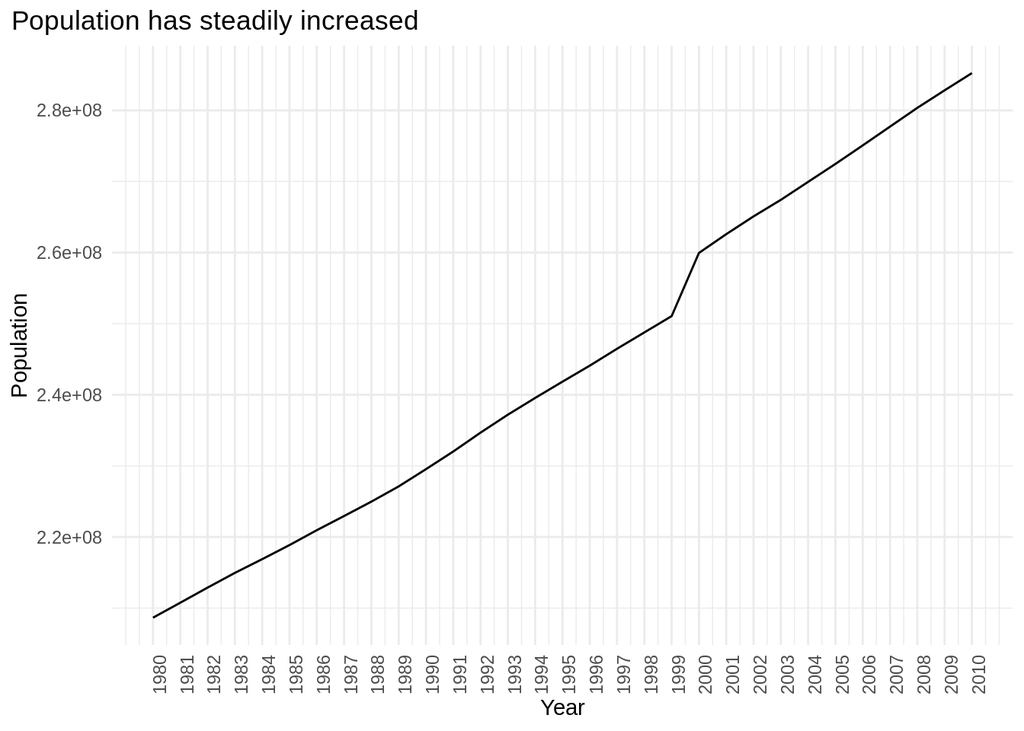

```r
DONOHUE_DF |>
  group_by(YEAR) |>
  summarise(Population = sum(Population)) |>
ggplot(aes(x = YEAR, y = Population)) +
  geom_line() +
  scale_x_continuous(
    breaks = seq(1980, 2010, by = 1),
    limits = c(1980, 2010),
    labels = c(seq(1980, 2010, by = 1))
  ) +
  labs(
    title = "Population has steadily increased",
    x = "Year",
    y = "Population"
  ) +
  theme_minimal() +
  theme(axis.text.x = element_text(angle = 90),
        plot.title.position = "plot")
```

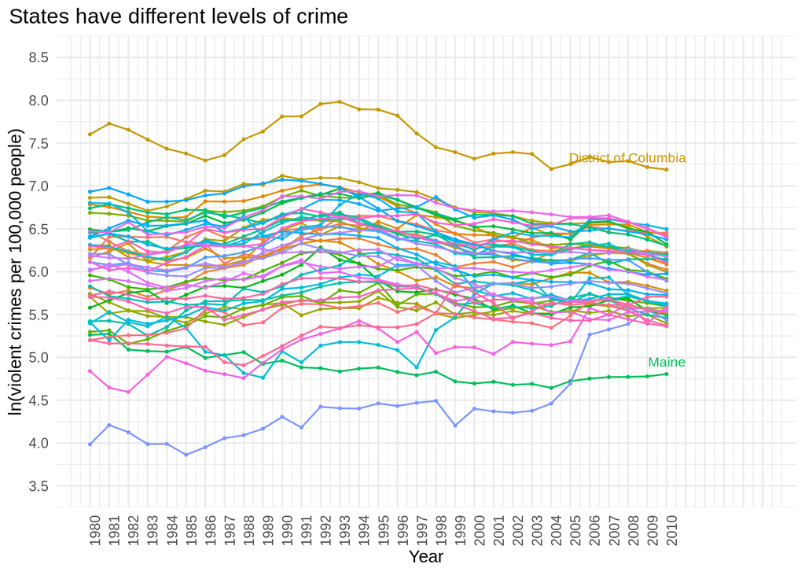

```r
p <- DONOHUE_DF |>
  mutate(Viol_crime_rate_100k_log = log((Viol_crime_count * 100000) / Population)) |>
  ggplot(aes(x = YEAR, y = Viol_crime_rate_100k_log, color = STATE)) +
  geom_point(size = 0.5) +
  geom_line(aes(group = STATE),
    size = 0.5,
    show.legend = FALSE
  ) +
  geom_text_repel(data = DONOHUE_DF |>
      mutate(Viol_crime_rate_100k_log = log((Viol_crime_count * 100000) / Population)) |>
      filter(YEAR == last(YEAR)),
      aes(label = STATE,x = YEAR, y = Viol_crime_rate_100k_log),
      size = 3, alpha = 1, nudge_x = 1, direction = "y",
      hjust = 1, vjust = 1, segment.size = 0.25, segment.alpha = 0.25,
      force = 1, max.iter = 9999) +
  guides(color = "none") +
  scale_x_continuous(
    breaks = seq(1980, 2015, by = 1),
    limits = c(1980, 2015),
    labels = c(seq(1980, 2010, by = 1), rep("", 5))
  ) +
  scale_y_continuous(
    breaks = seq(3.5, 8.5, by = 0.5),
    limits = c(3.5, 8.5)
  ) +
  labs(
    title = "States have different levels of crime",
    x = "Year", y = "ln(violent crimes per 100,000 people)"
  ) +
  theme_minimal() +
  theme(axis.text.x = element_text(angle = 90), plot.title.position = "plot")
p
```

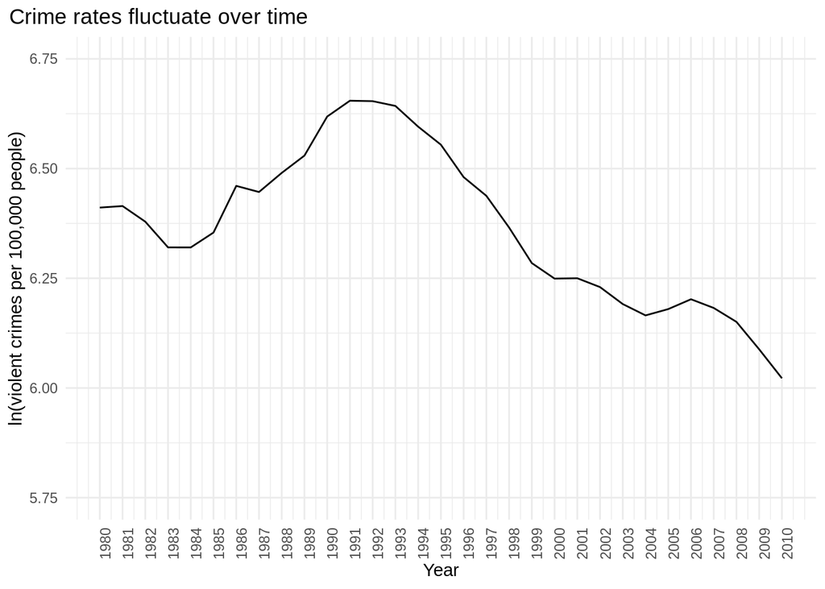

```r
df <- DONOHUE_DF |>
  group_by(YEAR) |>
  summarize(Viol_crime_count = sum(Viol_crime_count),
            Population = sum(Population),
            .groups = "drop") |>
  mutate(Viol_crime_rate_100k_log = log((Viol_crime_count * 100000) / Population))
df |>
  ggplot(aes(x = YEAR, y = Viol_crime_rate_100k_log)) +
  geom_line() +
  scale_x_continuous(
    breaks = seq(1980, 2010, by = 1),
    limits = c(1980, 2010),
    labels = c(seq(1980, 2010, by = 1))
  ) +
  scale_y_continuous(
    breaks = seq(5.75, 6.75, by = 0.25),
    limits = c(5.75, 6.75)
  ) +
  labs(
    title = "Crime rates fluctuate over time",
    x = "Year",
    y = "ln(violent crimes per 100,000 people)"
  ) +
  theme_minimal() +
  theme(axis.text.x = element_text(angle = 90),
        plot.title.position = "plot")
```

We summarize the police presence per 100k people by year and create a line graph to show how police presence has changed over time, including fluctuations

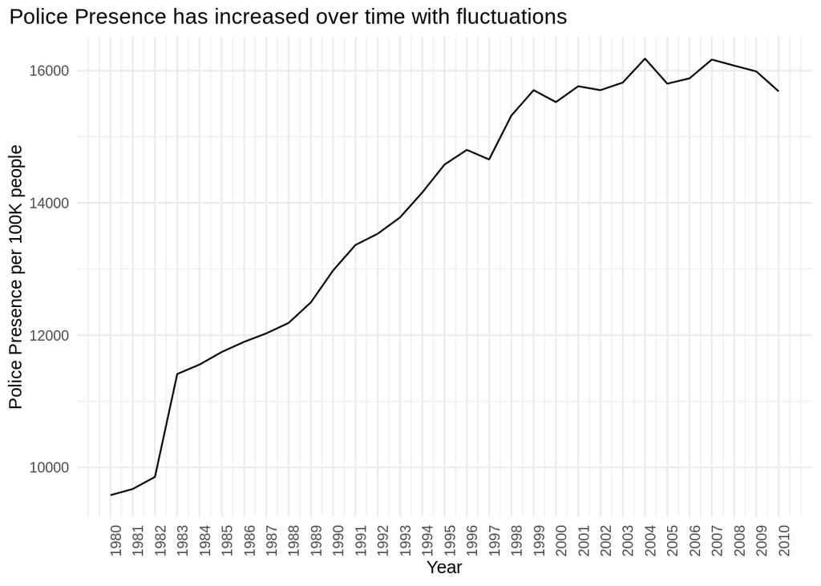

```r
DONOHUE_DF |>
  group_by(YEAR) |>
  summarise(Police = sum(police_per_100k_lag)) |>
  ggplot(aes(x = YEAR, y = Police)) +
  geom_line() +
  scale_x_continuous(
    breaks = seq(1980, 2010, by = 1),
    limits = c(1980, 2010),
    labels = c(seq(1980, 2010, by = 1))
  ) +
  labs(
    title = "Police Presence has increased over time with fluctuations",
    x = "Year",
    y = "Police Presence per 100K people"
  ) +
  theme_minimal() +
  theme(axis.text.x = element_text(angle = 90),
        plot.title.position = "plot")
```

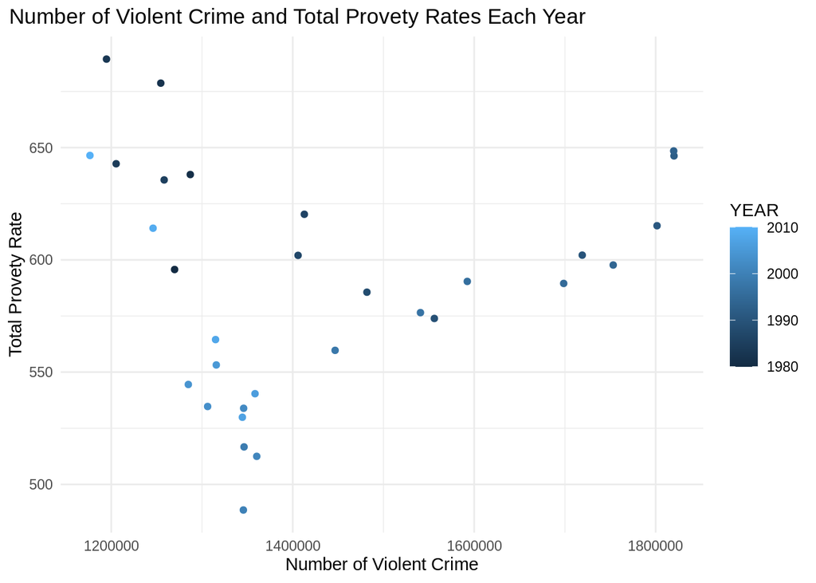

```r
df <- DONOHUE_DF |>
  group_by(YEAR) |>
  summarize(violence =  sum(Viol_crime_count),
            Provety = sum(Poverty_rate),
            .groups = "drop")
df |>
  ggplot(aes(x = violence, y = Provety, color =YEAR)) +
  geom_point() +
  labs(
    title = "Number of Violent Crime and Total Provety Rates Each Year",
    x = "Number of Violent Crime",
    y = "Total Provety Rate"
  ) +
  theme_minimal() +
  theme( plot.title.position = "plot")
```

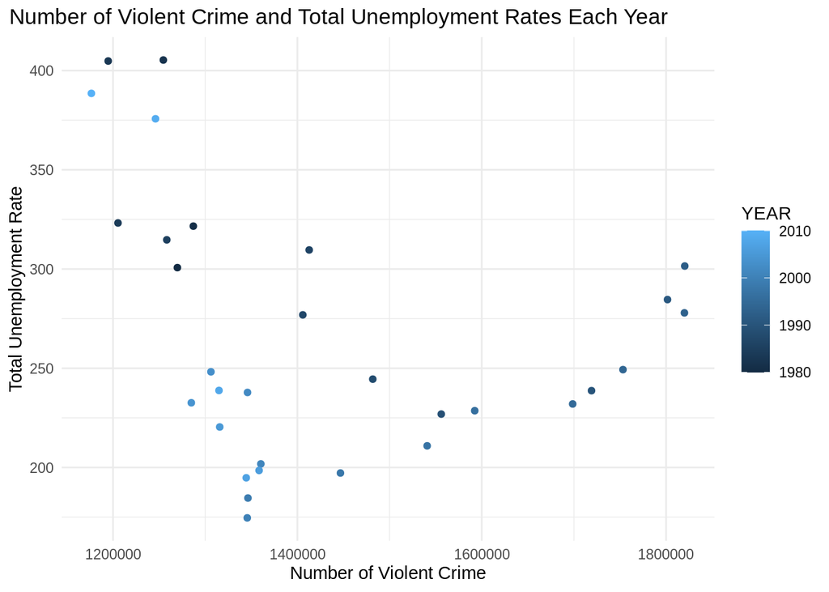

```r
df01<- LOTT_DF |>
  group_by(YEAR) |>
  summarise(Unemployment_rate = sum(Unemployment_rate), violence =  sum(Viol_crime_count) )
df01 |>
  ggplot(aes(x = violence, y = Unemployment_rate,  color =YEAR)) +
  geom_point() +
  labs(
    title = "Number of Violent Crime and Total Unemployment Rates Each Year",
    x = "Number of Violent Crime",
    y = "Total Unemployment Rate"
  ) +
  theme_minimal() +
  theme(plot.title.position = "plot")
```

We create a bar chart displays the total number of Police Presence by state. The x-axis represents the total number of Police Presence, while the y-axis represents each state.

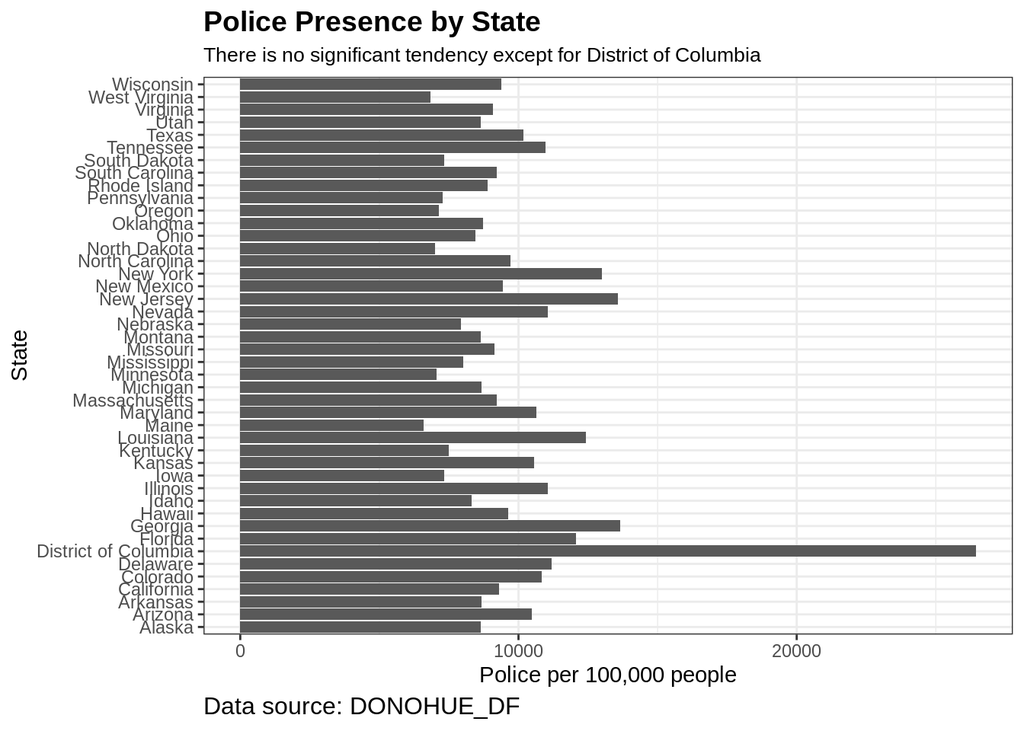

```r
ggplot(data=DONOHUE_DF, aes(x=police_per_100k_lag, y=STATE)) +
  geom_bar(stat="identity") +
  labs(x="Police per 100,000 people", y="State",
       title="Police Presence by State",
       subtitle="There is no significant tendency except for District of Columbia",
       caption="Data source: DONOHUE_DF") +
  theme_bw() +
  theme(plot.title = element_text(size=14, face="bold"),
        plot.subtitle = element_text(size=10),
        plot.caption = element_text(size=12, hjust=0))
```

We also create a bar chart using ggplot, which displays the total number of violent crimes by state. The x-axis represents the total number of violent crimes, while the y-axis represents each state.

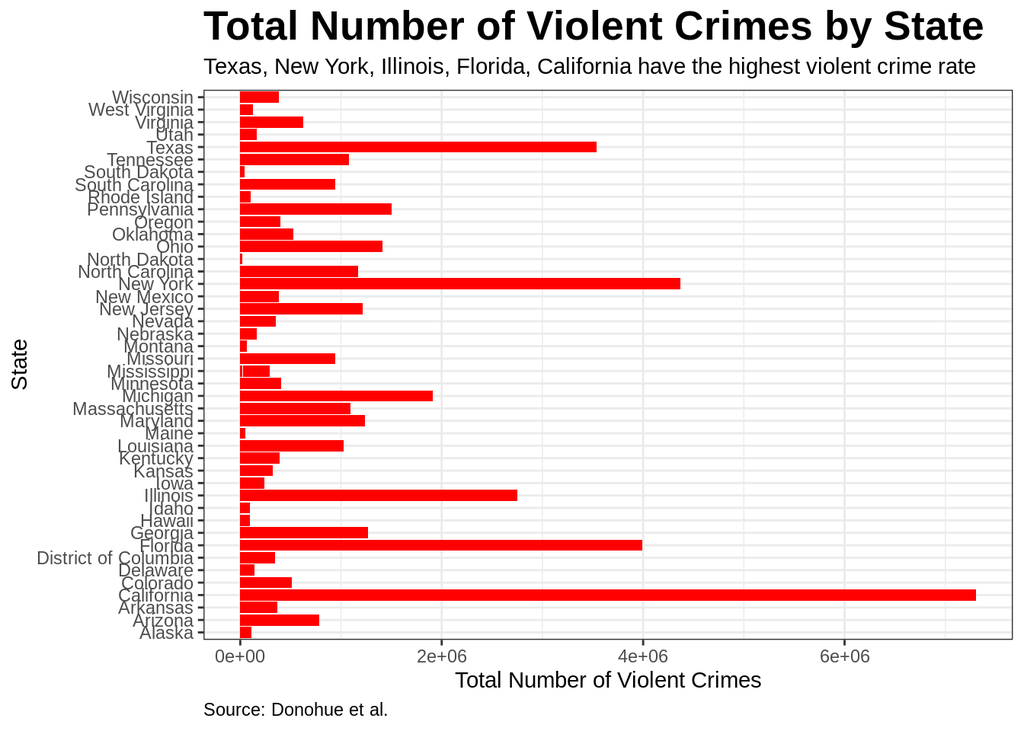

```r
ggplot(data=DONOHUE_DF, aes(x=Viol_crime_count, y=STATE)) +
  geom_bar(stat="identity", fill="red") +
  labs(x="Total Number of Violent Crimes", y="State",
       title="Total Number of Violent Crimes by State",
       subtitle="Texas, New York, Illinois, Florida, California have the highest violent crime rate ",
       caption="Source: Donohue et al.") +
  theme_bw() +
  theme(plot.title = element_text(size=20, face="bold"),
        plot.subtitle = element_text(size=11),
        plot.caption = element_text(hjust=0))
```